# Machine Learning to Classify Breast Tissue Leisions as Benign or Malignant

Karis Kang and Prof Fisk

Today, we are going to work with some real data and machine to get used to the process of using packages without *really* knowing what the package is doing.

UC Irvine provides a lot of data for oncology machine learning training. You are going to write a random forest classifier that will learn how to classify breast leisions as benign or malignant.

I’ve labelled the columns of the data for you. There are 32 columns, 30 of which contain data that we are going to use to train our model. One of the remaining columns (the first) is an ID that identifies the sample uniquely and the other (the second) contains the answer (known as the label) that we are going to train our machine learning algorithm to classify.

We are going to use the caret and randomForest packages to do so.

```r
if(!"caret"%in%installed.packages()){install.packages("caret", dependencies = TRUE)}
```

[output not shown]

```r
if(!"randomForest"%in%installed.packages()){install.packages("randomForest")}
library(caret)
library(randomForest)
```

Next, lets read in the data.

```r
#set FILENAME to be the location of the file on your computer
FILENAME<-"~/CMB523/Week 7/breastFNA.csv"
all_breast_data<-read.csv(FILENAME,header = T)
```

The above code should load the data in as a variable called “all_breast_data”. One common feature of machine learning classifiers is that we need to split the data we have into different pieces called training and testing. The training data is what the computer will use to analyze underlying and complex relationships between the data and the labels. The testing data is what we will use to determine if the machine learning algorithm worked well or not (that is, we leave some data out so we can give the program a test it doesn’t know the answer to).

```r
#<write a line of code that prints how many rows are in the data>
print(nrow(all_breast_data))
```

```
[1] 569
```

It is not uncommon to set aside around one-fifth of your data for testing. To make things easy to interpret, you will set aside 100 samples for testing. Split all_breast_data into two variables, one called testDat, containing 100 random rows from all_breast_data, and trainDat, containing the rest.

```r
set.seed(42666) #just makes it easier for Dr. Fisk to grade

#YOUR CODE HERE
rowvector <- 1:569
newvector <-sample(rowvector, 100, replace = FALSE)
testDat <- data.frame(all_breast_data[newvector,])
trainDat <- data.frame(all_breast_data[-newvector,])
#there are lots of ways to do this
#if you are having a hard time figuring out what to do
#then I recommend creating a vector of all the numbers between 1
#and the number of rows. Then, I would use the sample() function without replacement to randomly pick 100 row numbers from the aforementioned vector and save it as a new vector.
#Then, test would be testDat<-all_breast_data[new_vector,] and train would be trainDat<-all_breast_data[-new_vector,]
#however you do it is fine
```

Great! Now that you’ve split your data in two, we are going to train our machine learning model! We need to do just a bit of data cleaning first by converting our training label to something called a factor.

QUESTION 1: What is a factor data type in R?

**Answer 1: Factor data is a type of categorical data where there are a set number of character values data can be grouped in e.g. Pokemon types are factor data (“Grass”, “Fire”, “Psychic”)**

```r
#now we are going to train the model
#we are using the randomforest algorithm, which is 'rf' and what is called a 5 fold cross-validation where the algorithm is trained on random subsets of the data and tested to get initial accuracy.
model<-train(Diagnosis~.,
            data=trainDat,
            method ='rf',
            trControl=trainControl(method = "cv",number = 5)
)
#now we are going to train the model
#we are using the randomforest algorithm, which is 'rf' and what is called a 5 fold cross-validation where the algorithm is trained on random subsets of the data and tested to get initial accuracy.
model<-train(Diagnosis~.,
            data=trainDat,
            method ='rf',
            trControl=trainControl(method = "cv",number = 5)
)
print(model)
```

```
Random Forest

469 samples
 31 predictor
  2 classes: 'B', 'M'

No pre-processing
Resampling: Cross-Validated (5 fold)
Summary of sample sizes: 374, 376, 375, 376, 375
Resampling results across tuning parameters:

  mtry  Accuracy   Kappa
   2    0.9531204  0.8999817
  16    0.9616768  0.9174718
  31    0.9616997  0.9177430

Accuracy was used to select the optimal model using the largest value.
The final value used for the model was mtry = 31.
```

QUESTION 2: What mtry value had the best accuracy for your model?

**Answer 2: mtry =31 had the best accuracy at 0.9616997**

mtry is what is called a hyperparameter. It is basically a number that somehow shapes how well the machine learning model does. For random forests, they have a hyperparameter called mtry that decides how many variables are used at each split in the decision tree.

Now we are going to test our model on data it has never seen before (testDat) and see how well it learned.

```r
###AGAIN, NO NEED TO ALTER ANY OF THIS RIGHT NOW

#need to convert the diagnosis into a factor in the test data too
testDat$Diagnosis<-factor(testDat$Diagnosis)

#make the predictions and store them in a new column called prediction
testDat$Prediction<-predict(model, newdata = testDat)
```

Now your variable testDat has a new column with the predictions the machine model made, given the other columns. How did it do? You are going to write code to find out! The “Diagnosis” column has the true answers. The “Prediction” column has the predicted answers. Your task here is to determine for how many of the rows out of 100 they do not match.

```r
(nrow(testDat) - length(which(testDat$Diagnosis==testDat$Prediction)))/(nrow(testDat))
```

```
[1] 0.04
```

Below is code that will tell you the true diagnosis of those that the model misclassified. That is, when it was wrong, what was the right answer.

```r
#NO NEED FOR YOU TO ADD CODE HERE
print(summary(testDat[which(testDat$Diagnosis!=testDat$Prediction),"Diagnosis"]))
```

```
B M
4 0
```

QUESTION 3: In your results, was there a bias to which kind of leision was misclassified more often?

**Answer 3: Benign (B) lesions were more likely to be misclassified as malignant (M), than malignant as benign; aka, Type I error**

QUESTION 4: Do you think that it would be better for the machine learning algorithm to classify benign tumors as malignant or malignant tumors as benign. What other information might you want to make that decision? (Not really a right or wrong questions, but making you think about what your data looks like)

**Answer 4:In the case of cancer diagnosis, Type I errors are preferable if error is present; better to scare someone with a misdiagnosis of malignancy that turns out to be benign, rather than miss a malignant tumor**

There are only 2 outcomes the model could decide: B or M.

QUESTION 5: If you or your model just guessed at random (equal chance in this case), what do you expect your accuracy to be?

**Answer 5: If the model were to guess at random, there would be a 50:50 chance of getting the prediction correct aka accuracy = 0.50**

There might be more to it than you thought at first glance. Lets think back to all the data. How many samples in the training data are B and how many are M?

```r
#NO NEED TO ADD CODE HERE
print(table(all_breast_data$Diagnosis))
```

```
  B   M
357 212
```

```r
print(table(all_breast_data$Diagnosis)/nrow(all_breast_data))
```

```
        B         M
0.6274165 0.3725835
```

Why is this important? In your projects (and in your life!) understanding what we expect to see is key to understanding whether or not what we see is surprising or important. In this case, the dumbest model could achieve 63% accuracy by just always guessing benign. So if you wrote a program that gave you an accuracy of, say, 70%, that would not actually be a very impressive machine learning program!

Think critically about your data whenever you can. Ask “are the characteristics uniformly distributed among members of my data?” or more simply “what do I expect to see and how often do I expect to see it”.

We are going to see if doing any preprocessing of our data helps with the outcome at all. The chances are it probably won’t for a random forest, but it is good practice all the same. All the new bit of code below does is change the numbers such that they are centered about a single number and scaled proportionally between 0 and 1. There are reasons this can help not worth getting into today.

```r
#NO NEED FOR YOU TO ALTER THIS CODE
#Same thing but with preprocessing
#You can use this block of code again down below.
model2<-train(Diagnosis~.,
            data=trainDat,
            method ='rf',
            preProc=c("center","scale"), #note this line
            trControl=trainControl(method = "cv",number = 5)
)

testDat$Prediction2<-predict(model2, newdata = testDat)
print(summary(testDat[which(testDat$Diagnosis!=testDat$Prediction2),"Diagnosis"]))
```

```
B M
3 0
```

Here is where I leave you with one last counter-intuitive fact about working with data.

More isn’t always better.

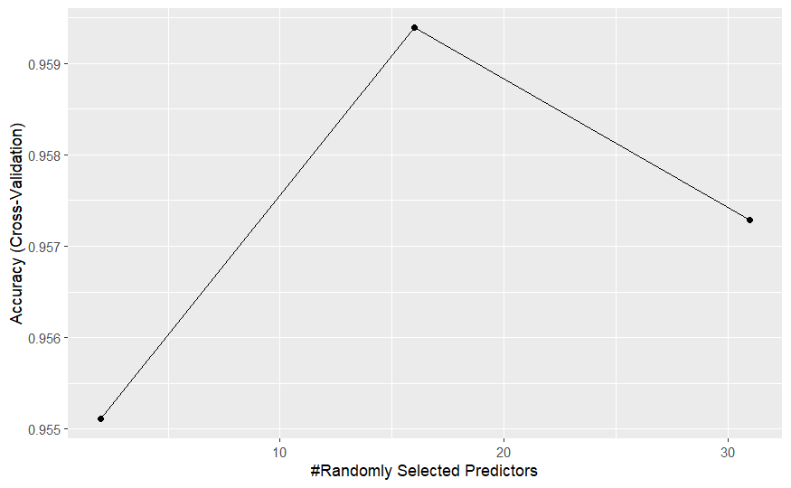

```r
# NO NEED FOR YOU TO ALTER THE CODE HERE
#plot the model
ggplot(model2)
```

A fundamental task and skill of scientific computing and the analysis of biological data is using your biological knowledge and your tech skills to determine what to include and what to exclude from your data in a way that doesn’t also just bias the answer to what you want to see.

A delicate balance indeed!

You last task for today is to repeat the process of training the data, predicting the diagnoses, and calculating the % correct and which ones were wrong using a different machine learning method. [A list of available models compatable can be found here.](https://topepo.github.io/caret/available-models.html) Remember that you are performing a classification task, so don’t use a regression model. You may need to install another packackage(s) to get the code to work. But ultimately, your should really have to change the method=“rf” parameter from the train function above. Plot the model once it is done training, like I did above with the ggplot function.

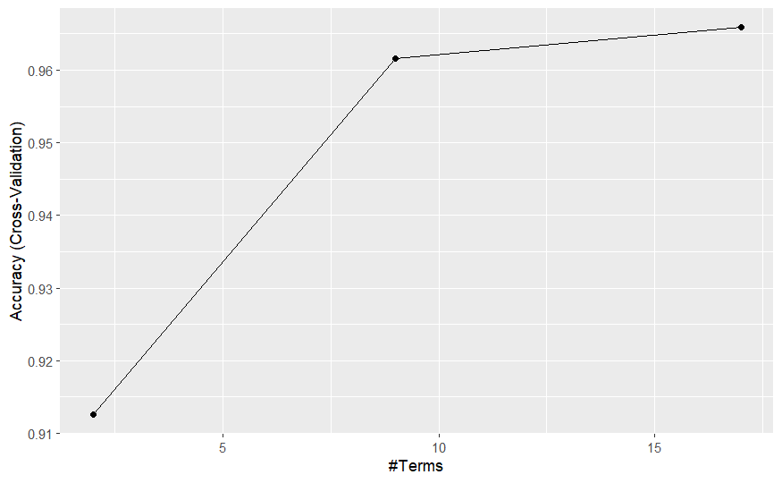

QUESTION 6: What did you think of this assignment?

**Answer 6: I did this assignment very late, and I wish I hadn’t so that I could have spent more time exploring the code - it’s interesting to see the modeling tools that are out there even if I don’t fully understand them, and get a feel for how different models takes different snapshots of the data to create predictions.**